# Multivariate Data

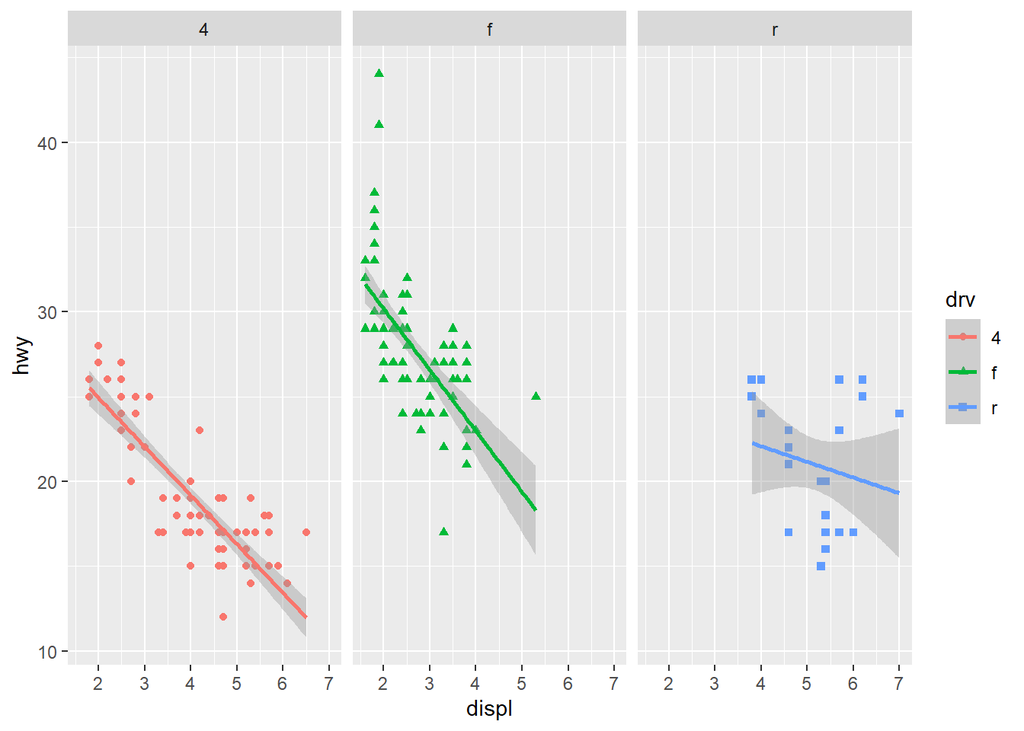

```r
> qplot(displ, hwy, data = mpg, shape = drv, color = drv,
+       geom = c("point", "smooth"), method = "lm", facets = .~drv)
Warning: Ignoring unknown parameters: method
`geom_smooth()` using formula 'y ~ x'
```

Using the `Cars93` data frame

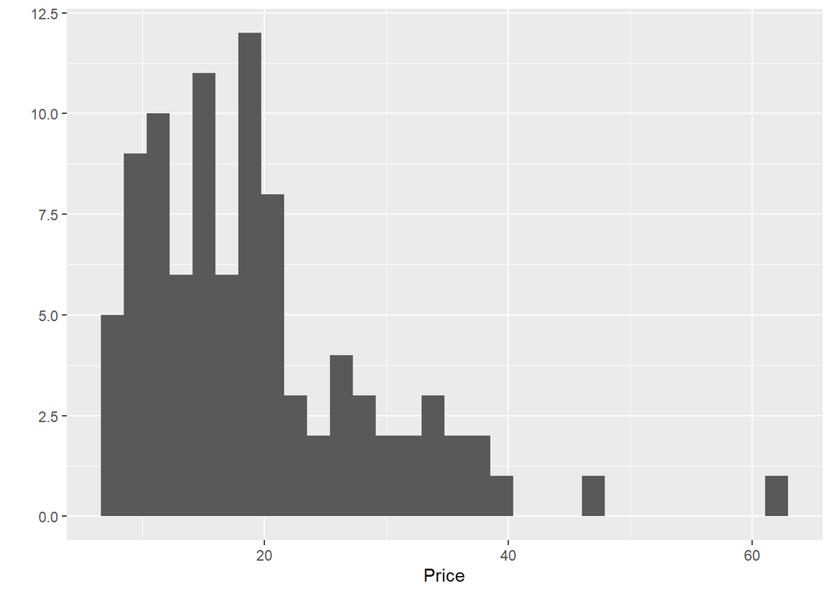

```r
> qplot(Price, data = Cars93, geom= "histogram")
`stat_bin()` using `bins = 30`. Pick better value with `binwidth`.
```

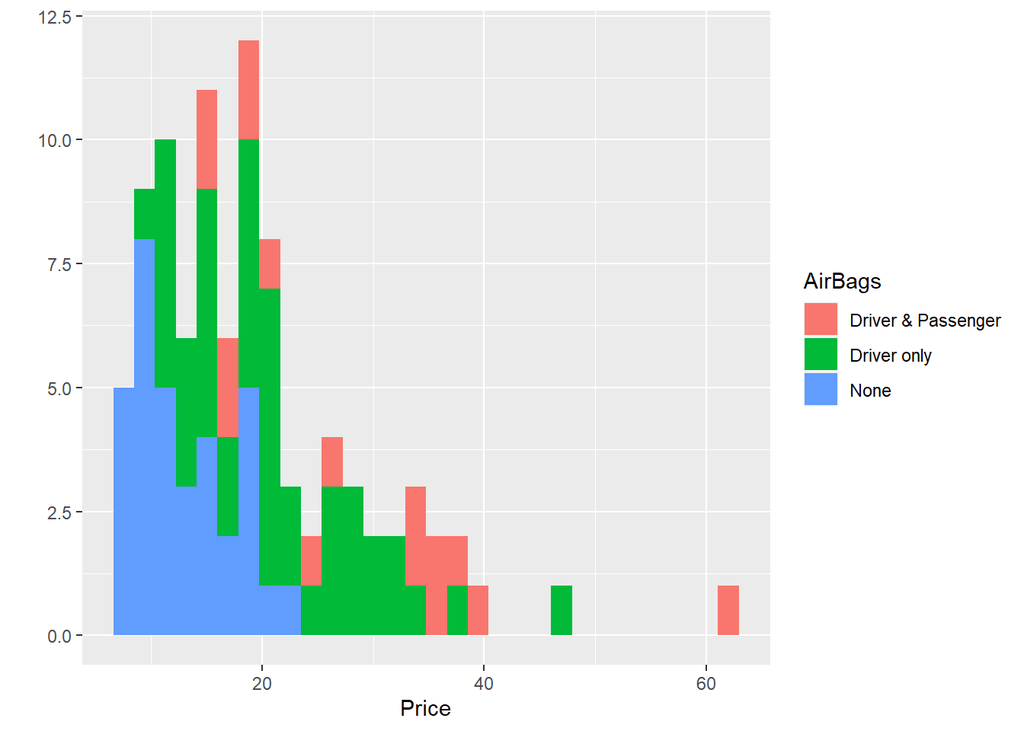

```r
> qplot(Price, data = Cars93, geom= "histogram",
+       fill = AirBags)
`stat_bin()` using `bins = 30`. Pick better value with `binwidth`.
```

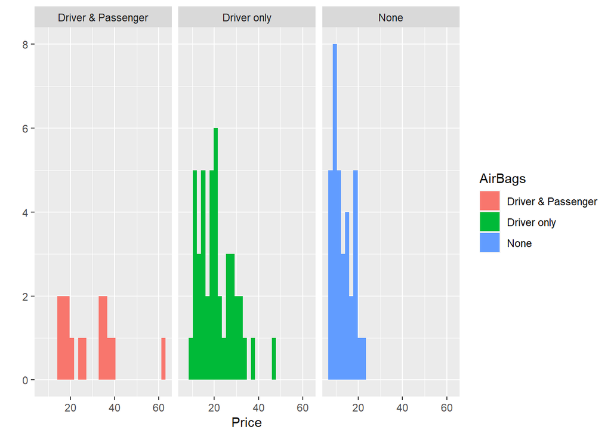

```r
> qplot(Price, data = Cars93, geom= "histogram",
+       fill = AirBags, facets = .~AirBags)
`stat_bin()` using `bins = 30`. Pick better value with `binwidth`.
```

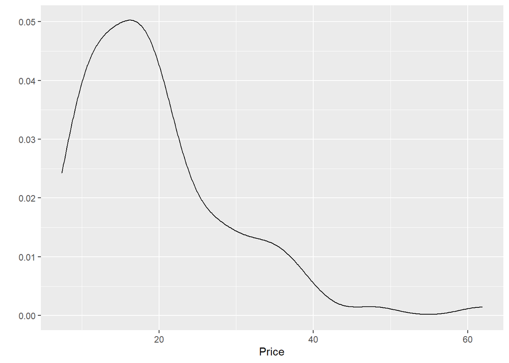

```r
> qplot(Price, data = Cars93, geom= "density")
```

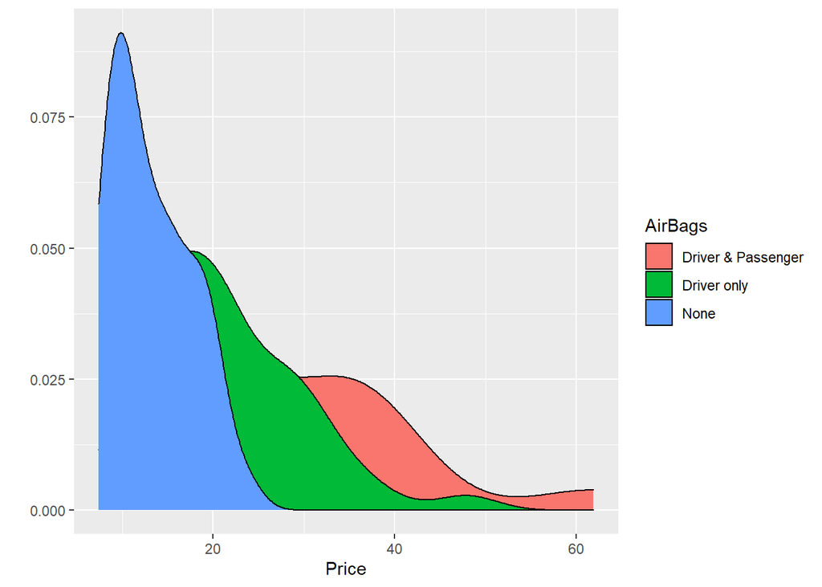

```r
> qplot(Price, data = Cars93, geom= "density",
+       fill = AirBags)
```

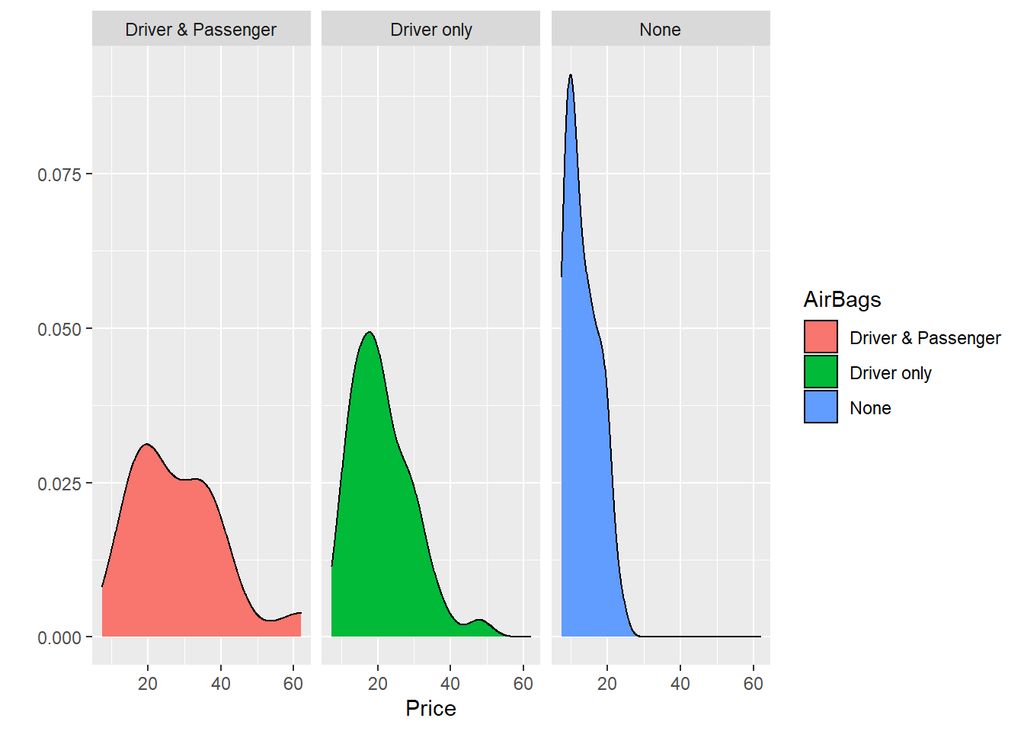

```r
> qplot(Price, data = Cars93, geom= "density",
+       fill = AirBags, facets = .~AirBags)
```

Boxplots from the `PlanthGrowth` example

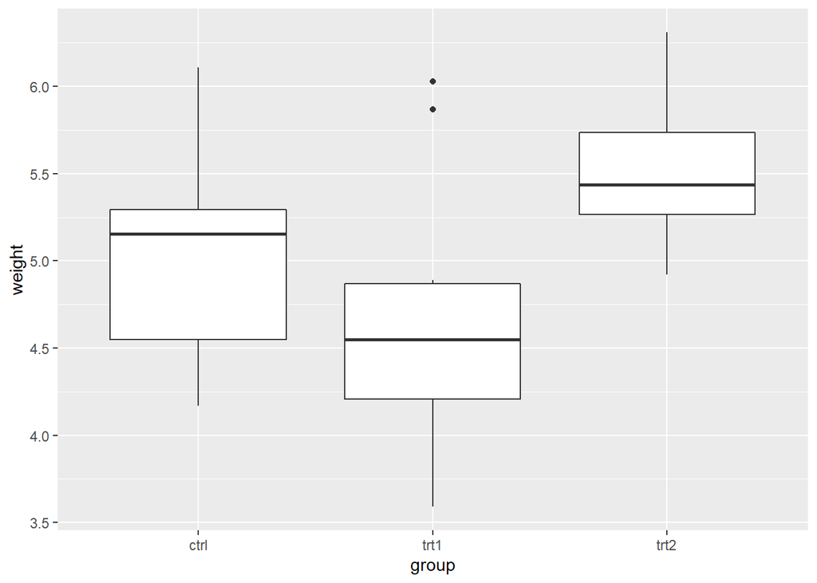

```r
> qplot(group, weight, data = PlantGrowth, geom = "boxplot")
```

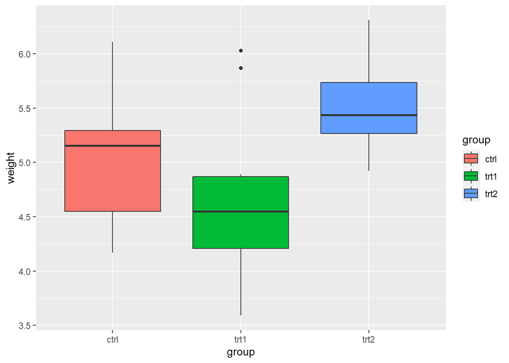

```r
> qplot(group, weight, data = PlantGrowth, geom = "boxplot",
+       fill = group)
```

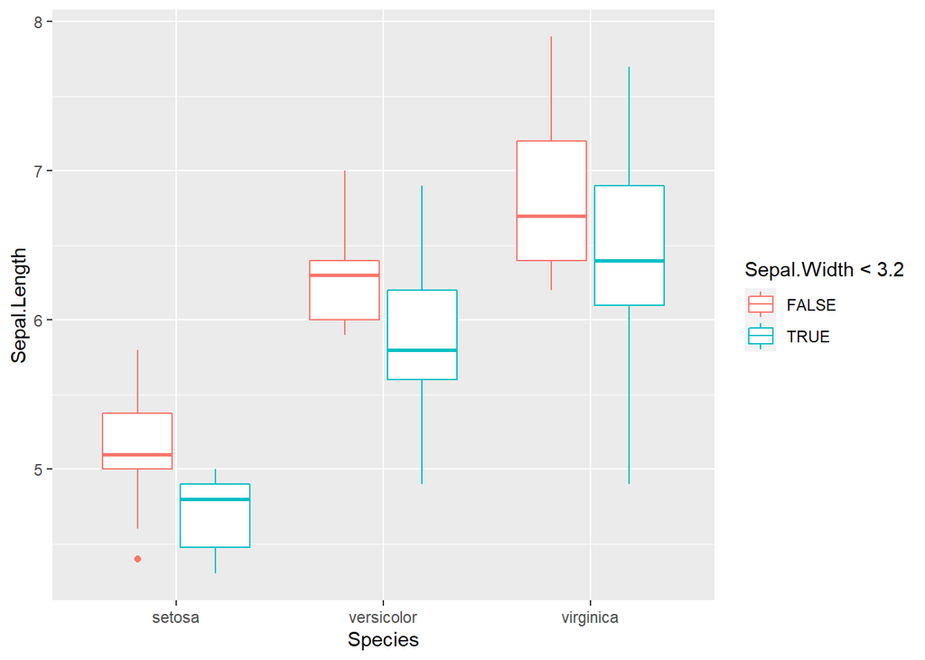

```r
> ggplot(data = iris, aes(Species, Sepal.Length)) +
+   geom_boxplot(aes(colour = Sepal.Width < 3.2))
```

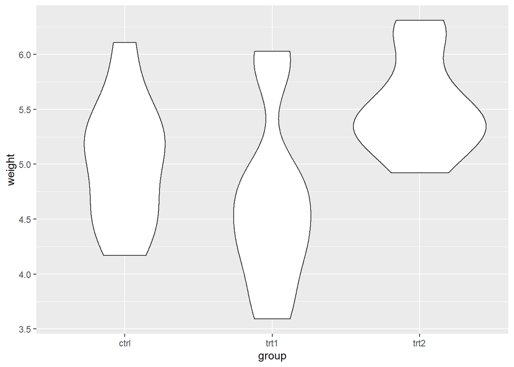

```r
> qplot(group, weight, data = PlantGrowth, geom = "violin")
```

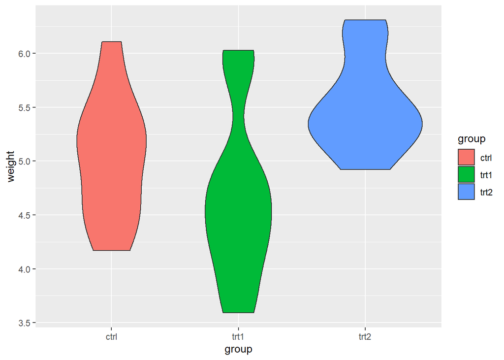

```r
> qplot(group, weight, data = PlantGrowth, geom = "violin",
+       fill = group)
```

Let’s now review the prices of 50 000 diamonds from the `dimonds` data frame from `ggplot2` package, where `price` is the price of diamond in US dollars and cut is the quality of cut (Fair, Good, Very Good, Premium, Ideal). Make a frequency polygon for the prices depending on the cut quality.

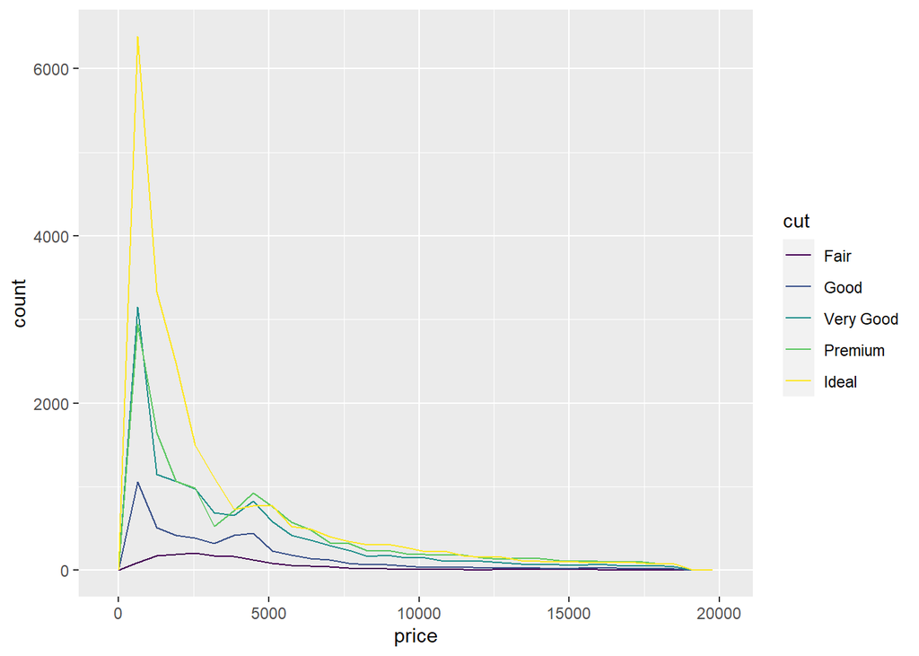

```r
> ggplot(diamonds, aes(price, colour = cut)) +
+   geom_freqpoly()
`stat_bin()` using `bins = 30`. Pick better value with `binwidth`.
```